# Optimal Treatment Analysis

## Outcome Variable

**Outcome Variable:** ever_stunted

## Predictor Variables

**Intervention Variable:** single

**Adjustment Set:**

- arm
- W_mage
- meducyrs
- feducyrs
- W_mhtcm
- W_mwtkg
- W_mbmi
- delta_W_mage
- delta_meducyrs
- delta_feducyrs
- delta_W_mhtcm
- delta_W_mwtkg
- delta_W_mbmi

## Stratifying Variables

The analysis was stratified on these variable(s):

- agecat
- studyid
- country

## Data Summary

| agecat | studyid | country | single | ever_stunted | n_cell | n |
| --- | --- | --- | --- | --- | --- | --- |
| 0-24 months | ki0047075b-MAL-ED | BANGLADESH | 0 | 0 | 104 | 265 |
| 0-24 months | ki0047075b-MAL-ED | BANGLADESH | 0 | 1 | 161 | 265 |
| 0-24 months | ki0047075b-MAL-ED | BANGLADESH | 1 | 0 | 0 | 265 |
| 0-24 months | ki0047075b-MAL-ED | BANGLADESH | 1 | 1 | 0 | 265 |
| 0-24 months | ki0047075b-MAL-ED | BRAZIL | 0 | 0 | 154 | 233 |
| 0-24 months | ki0047075b-MAL-ED | BRAZIL | 0 | 1 | 43 | 233 |
| 0-24 months | ki0047075b-MAL-ED | BRAZIL | 1 | 0 | 25 | 233 |
| 0-24 months | ki0047075b-MAL-ED | BRAZIL | 1 | 1 | 11 | 233 |
| 0-24 months | ki0047075b-MAL-ED | INDIA | 0 | 0 | 101 | 249 |
| 0-24 months | ki0047075b-MAL-ED | INDIA | 0 | 1 | 148 | 249 |
| 0-24 months | ki0047075b-MAL-ED | INDIA | 1 | 0 | 0 | 249 |
| 0-24 months | ki0047075b-MAL-ED | INDIA | 1 | 1 | 0 | 249 |
| 0-24 months | ki0047075b-MAL-ED | NEPAL | 0 | 0 | 157 | 240 |
| 0-24 months | ki0047075b-MAL-ED | NEPAL | 0 | 1 | 83 | 240 |
| 0-24 months | ki0047075b-MAL-ED | NEPAL | 1 | 0 | 0 | 240 |
| 0-24 months | ki0047075b-MAL-ED | NEPAL | 1 | 1 | 0 | 240 |
| 0-24 months | ki0047075b-MAL-ED | PERU | 0 | 0 | 101 | 303 |
| 0-24 months | ki0047075b-MAL-ED | PERU | 0 | 1 | 167 | 303 |
| 0-24 months | ki0047075b-MAL-ED | PERU | 1 | 0 | 14 | 303 |
| 0-24 months | ki0047075b-MAL-ED | PERU | 1 | 1 | 21 | 303 |
| 0-24 months | ki0047075b-MAL-ED | SOUTH AFRICA | 0 | 0 | 82 | 314 |
| 0-24 months | ki0047075b-MAL-ED | SOUTH AFRICA | 0 | 1 | 94 | 314 |
| 0-24 months | ki0047075b-MAL-ED | SOUTH AFRICA | 1 | 0 | 61 | 314 |
| 0-24 months | ki0047075b-MAL-ED | SOUTH AFRICA | 1 | 1 | 77 | 314 |
| 0-24 months | ki0047075b-MAL-ED | TANZANIA, UNITED REPUBLIC OF | 0 | 0 | 38 | 262 |
| 0-24 months | ki0047075b-MAL-ED | TANZANIA, UNITED REPUBLIC OF | 0 | 1 | 214 | 262 |
| 0-24 months | ki0047075b-MAL-ED | TANZANIA, UNITED REPUBLIC OF | 1 | 0 | 3 | 262 |
| 0-24 months | ki0047075b-MAL-ED | TANZANIA, UNITED REPUBLIC OF | 1 | 1 | 7 | 262 |
| 0-24 months | ki1066203-TanzaniaChild2 | TANZANIA, UNITED REPUBLIC OF | 0 | 0 | 1400 | 2375 |
| 0-24 months | ki1066203-TanzaniaChild2 | TANZANIA, UNITED REPUBLIC OF | 0 | 1 | 751 | 2375 |

[output cut: 138 more lines]

The following strata were considered:

- agecat: 0-24 months, studyid: ki0047075b-MAL-ED, country: BANGLADESH
- agecat: 0-24 months, studyid: ki0047075b-MAL-ED, country: BRAZIL
- agecat: 0-24 months, studyid: ki0047075b-MAL-ED, country: INDIA
- agecat: 0-24 months, studyid: ki0047075b-MAL-ED, country: NEPAL
- agecat: 0-24 months, studyid: ki0047075b-MAL-ED, country: PERU
- agecat: 0-24 months, studyid: ki0047075b-MAL-ED, country: SOUTH AFRICA
- agecat: 0-24 months, studyid: ki0047075b-MAL-ED, country: TANZANIA, UNITED REPUBLIC OF
- agecat: 0-24 months, studyid: ki1066203-TanzaniaChild2, country: TANZANIA, UNITED REPUBLIC OF
- agecat: 0-24 months, studyid: ki1112895-Guatemala BSC, country: GUATEMALA
- agecat: 0-24 months, studyid: ki1119695-PROBIT, country: BELARUS
- agecat: 0-24 months, studyid: ki1126311-ZVITAMBO, country: ZIMBABWE
- agecat: 0-24 months, studyid: ki1135781-COHORTS, country: GUATEMALA
- agecat: 0-24 months, studyid: ki1135781-COHORTS, country: INDIA
- agecat: 0-24 months, studyid: ki1135781-COHORTS, country: PHILIPPINES
- agecat: 0-6 months, studyid: ki0047075b-MAL-ED, country: BANGLADESH
- agecat: 0-6 months, studyid: ki0047075b-MAL-ED, country: BRAZIL
- agecat: 0-6 months, studyid: ki0047075b-MAL-ED, country: INDIA
- agecat: 0-6 months, studyid: ki0047075b-MAL-ED, country: NEPAL
- agecat: 0-6 months, studyid: ki0047075b-MAL-ED, country: PERU
- agecat: 0-6 months, studyid: ki0047075b-MAL-ED, country: SOUTH AFRICA
- agecat: 0-6 months, studyid: ki0047075b-MAL-ED, country: TANZANIA, UNITED REPUBLIC OF
- agecat: 0-6 months, studyid: ki1066203-TanzaniaChild2, country: TANZANIA, UNITED REPUBLIC OF
- agecat: 0-6 months, studyid: ki1112895-Guatemala BSC, country: GUATEMALA
- agecat: 0-6 months, studyid: ki1119695-PROBIT, country: BELARUS
- agecat: 0-6 months, studyid: ki1126311-ZVITAMBO, country: ZIMBABWE
- agecat: 0-6 months, studyid: ki1135781-COHORTS, country: GUATEMALA
- agecat: 0-6 months, studyid: ki1135781-COHORTS, country: INDIA
- agecat: 0-6 months, studyid: ki1135781-COHORTS, country: PHILIPPINES
- agecat: 6-24 months, studyid: ki0047075b-MAL-ED, country: BANGLADESH
- agecat: 6-24 months, studyid: ki0047075b-MAL-ED, country: BRAZIL
- agecat: 6-24 months, studyid: ki0047075b-MAL-ED, country: INDIA
- agecat: 6-24 months, studyid: ki0047075b-MAL-ED, country: NEPAL
- agecat: 6-24 months, studyid: ki0047075b-MAL-ED, country: PERU
- agecat: 6-24 months, studyid: ki0047075b-MAL-ED, country: SOUTH AFRICA
- agecat: 6-24 months, studyid: ki0047075b-MAL-ED, country: TANZANIA, UNITED REPUBLIC OF
- agecat: 6-24 months, studyid: ki1066203-TanzaniaChild2, country: TANZANIA, UNITED REPUBLIC OF
- agecat: 6-24 months, studyid: ki1112895-Guatemala BSC, country: GUATEMALA
- agecat: 6-24 months, studyid: ki1119695-PROBIT, country: BELARUS
- agecat: 6-24 months, studyid: ki1126311-ZVITAMBO, country: ZIMBABWE
- agecat: 6-24 months, studyid: ki1135781-COHORTS, country: GUATEMALA
- agecat: 6-24 months, studyid: ki1135781-COHORTS, country: INDIA
- agecat: 6-24 months, studyid: ki1135781-COHORTS, country: PHILIPPINES

### Dropped Strata

Some strata were dropped due to rare outcomes:

- agecat: 0-24 months, studyid: ki0047075b-MAL-ED, country: BANGLADESH
- agecat: 0-24 months, studyid: ki0047075b-MAL-ED, country: INDIA
- agecat: 0-24 months, studyid: ki0047075b-MAL-ED, country: NEPAL
- agecat: 0-24 months, studyid: ki0047075b-MAL-ED, country: TANZANIA, UNITED REPUBLIC OF
- agecat: 0-24 months, studyid: ki1135781-COHORTS, country: INDIA
- agecat: 0-6 months, studyid: ki0047075b-MAL-ED, country: BANGLADESH
- agecat: 0-6 months, studyid: ki0047075b-MAL-ED, country: INDIA
- agecat: 0-6 months, studyid: ki0047075b-MAL-ED, country: NEPAL
- agecat: 0-6 months, studyid: ki0047075b-MAL-ED, country: TANZANIA, UNITED REPUBLIC OF
- agecat: 0-6 months, studyid: ki1135781-COHORTS, country: INDIA
- agecat: 6-24 months, studyid: ki0047075b-MAL-ED, country: BANGLADESH
- agecat: 6-24 months, studyid: ki0047075b-MAL-ED, country: BRAZIL
- agecat: 6-24 months, studyid: ki0047075b-MAL-ED, country: INDIA
- agecat: 6-24 months, studyid: ki0047075b-MAL-ED, country: NEPAL
- agecat: 6-24 months, studyid: ki0047075b-MAL-ED, country: TANZANIA, UNITED REPUBLIC OF
- agecat: 6-24 months, studyid: ki1135781-COHORTS, country: INDIA

## Methods Detail

We’re interested in the causal parameters $E[Y_a]$ for all values of $a \in \mathcal{A}$. These parameters represent the mean outcome if, possibly contrary to fact, we intervened to set all units to have $A=a$. Under the randomization and positivity assumptions, these are identified by the statistical parameters $\psi_a=E_W[E_{Y|A,W}(Y|A=a,W)]$. In addition, we’re interested in the mean of $Y$, $E[Y]$ under no intervention (the observed mean). We will estimate these parameters by using SuperLearner to fit the relevant likelihood factors – $E_{Y|A,W}(Y|A=a,W)$ and $p(A=a|W)$, and then updating our likelihood fit using a joint TMLE.

For unadjusted analyses ($W=\{\}$), initial likelihoods were estimated using Lrnr_glm to estimate the simple $E(Y|A)$ and Lrnr_mean to estimate $p(A)$. For adjusted analyses, a small library containing Lrnr_glmnet, Lrnr_xgboost, and Lrnr_mean was used.

Having estimated these parameters, we will then use the delta method to estimate relative risks and attributable risks relative to a prespecified baseline level of $A$.

# Results Detail

## Results Plots

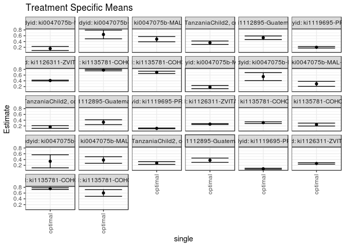

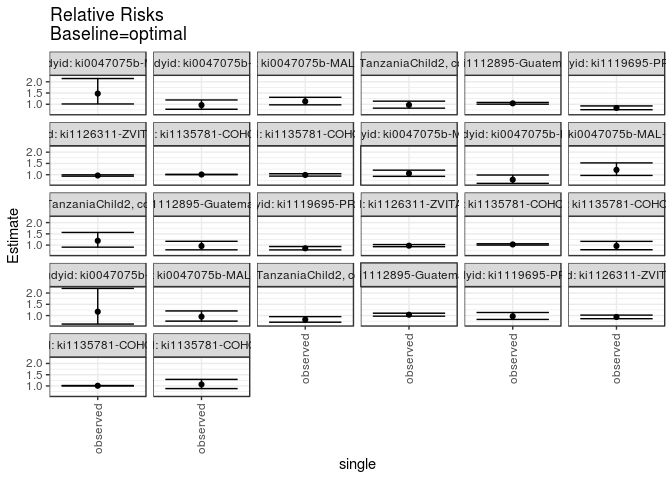

## Results Table

### Parameter: TSM

| agecat | studyid | country | intervention_level | baseline_level | estimate | ci_lower | ci_upper |
| --- | --- | --- | --- | --- | --- | --- | --- |
| 0-24 months | ki0047075b-MAL-ED | BRAZIL | optimal | NA | 0.1572399 | 0.0870868 | 0.2273930 |
| 0-24 months | ki0047075b-MAL-ED | PERU | optimal | NA | 0.6447514 | 0.4942841 | 0.7952187 |
| 0-24 months | ki0047075b-MAL-ED | SOUTH AFRICA | optimal | NA | 0.4824145 | 0.3908545 | 0.5739746 |
| 0-24 months | ki1066203-TanzaniaChild2 | TANZANIA, UNITED REPUBLIC OF | optimal | NA | 0.3587375 | 0.2981982 | 0.4192768 |
| 0-24 months | ki1112895-Guatemala BSC | GUATEMALA | optimal | NA | 0.5312169 | 0.4694207 | 0.5930131 |
| 0-24 months | ki1119695-PROBIT | BELARUS | optimal | NA | 0.1999711 | 0.1733574 | 0.2265848 |
| 0-24 months | ki1126311-ZVITAMBO | ZIMBABWE | optimal | NA | 0.4114933 | 0.3965450 | 0.4264417 |
| 0-24 months | ki1135781-COHORTS | GUATEMALA | optimal | NA | 0.7735537 | 0.7488238 | 0.7982837 |
| 0-24 months | ki1135781-COHORTS | PHILIPPINES | optimal | NA | 0.6949840 | 0.6550416 | 0.7349263 |
| 0-6 months | ki0047075b-MAL-ED | BRAZIL | optimal | NA | 0.1830422 | 0.1288719 | 0.2372125 |
| 0-6 months | ki0047075b-MAL-ED | PERU | optimal | NA | 0.5473973 | 0.4096031 | 0.6851915 |
| 0-6 months | ki0047075b-MAL-ED | SOUTH AFRICA | optimal | NA | 0.2965878 | 0.2112144 | 0.3819613 |
| 0-6 months | ki1066203-TanzaniaChild2 | TANZANIA, UNITED REPUBLIC OF | optimal | NA | 0.1641974 | 0.1174583 | 0.2109366 |
| 0-6 months | ki1112895-Guatemala BSC | GUATEMALA | optimal | NA | 0.3299121 | 0.2450465 | 0.4147777 |
| 0-6 months | ki1119695-PROBIT | BELARUS | optimal | NA | 0.1157409 | 0.1019436 | 0.1295382 |
| 0-6 months | ki1126311-ZVITAMBO | ZIMBABWE | optimal | NA | 0.2645584 | 0.2497372 | 0.2793796 |
| 0-6 months | ki1135781-COHORTS | GUATEMALA | optimal | NA | 0.3148658 | 0.2845977 | 0.3451340 |
| 0-6 months | ki1135781-COHORTS | PHILIPPINES | optimal | NA | 0.2477144 | 0.1980818 | 0.2973469 |
| 6-24 months | ki0047075b-MAL-ED | PERU | optimal | NA | 0.3380814 | 0.1108823 | 0.5652804 |
| 6-24 months | ki0047075b-MAL-ED | SOUTH AFRICA | optimal | NA | 0.3830424 | 0.2687726 | 0.4973123 |
| 6-24 months | ki1066203-TanzaniaChild2 | TANZANIA, UNITED REPUBLIC OF | optimal | NA | 0.2779244 | 0.2297747 | 0.3260742 |
| 6-24 months | ki1112895-Guatemala BSC | GUATEMALA | optimal | NA | 0.3755767 | 0.3020144 | 0.4491390 |
| 6-24 months | ki1119695-PROBIT | BELARUS | optimal | NA | 0.0792721 | 0.0616341 | 0.0969102 |
| 6-24 months | ki1126311-ZVITAMBO | ZIMBABWE | optimal | NA | 0.2625356 | 0.2378552 | 0.2872159 |
| 6-24 months | ki1135781-COHORTS | GUATEMALA | optimal | NA | 0.7545567 | 0.7238951 | 0.7852182 |
| 6-24 months | ki1135781-COHORTS | PHILIPPINES | optimal | NA | 0.6037131 | 0.4875088 | 0.7199175 |

### Parameter: E(Y)

| agecat | studyid | country | intervention_level | baseline_level | estimate | ci_lower | ci_upper |
| --- | --- | --- | --- | --- | --- | --- | --- |
| 0-24 months | ki0047075b-MAL-ED | BRAZIL | observed | NA | 0.2317597 | 0.1774632 | 0.2860561 |
| 0-24 months | ki0047075b-MAL-ED | PERU | observed | NA | 0.6204620 | 0.5657315 | 0.6751926 |
| 0-24 months | ki0047075b-MAL-ED | SOUTH AFRICA | observed | NA | 0.5445860 | 0.4894148 | 0.5997572 |
| 0-24 months | ki1066203-TanzaniaChild2 | TANZANIA, UNITED REPUBLIC OF | observed | NA | 0.3482105 | 0.3290467 | 0.3673744 |
| 0-24 months | ki1112895-Guatemala BSC | GUATEMALA | observed | NA | 0.5531915 | 0.4950624 | 0.6113206 |
| 0-24 months | ki1119695-PROBIT | BELARUS | observed | NA | 0.1674854 | 0.1488048 | 0.1861659 |
| 0-24 months | ki1126311-ZVITAMBO | ZIMBABWE | observed | NA | 0.3967178 | 0.3886181 | 0.4048175 |
| 0-24 months | ki1135781-COHORTS | GUATEMALA | observed | NA | 0.7796189 | 0.7562250 | 0.8030128 |
| 0-24 months | ki1135781-COHORTS | PHILIPPINES | observed | NA | 0.6868787 | 0.6703303 | 0.7034272 |
| 0-6 months | ki0047075b-MAL-ED | BRAZIL | observed | NA | 0.1931330 | 0.1423366 | 0.2439295 |
| 0-6 months | ki0047075b-MAL-ED | PERU | observed | NA | 0.4257426 | 0.3699763 | 0.4815088 |
| 0-6 months | ki0047075b-MAL-ED | SOUTH AFRICA | observed | NA | 0.3598726 | 0.3067005 | 0.4130447 |
| 0-6 months | ki1066203-TanzaniaChild2 | TANZANIA, UNITED REPUBLIC OF | observed | NA | 0.1957895 | 0.1798275 | 0.2117515 |
| 0-6 months | ki1112895-Guatemala BSC | GUATEMALA | observed | NA | 0.3169811 | 0.2608532 | 0.3731091 |
| 0-6 months | ki1119695-PROBIT | BELARUS | observed | NA | 0.0995087 | 0.0864641 | 0.1125533 |
| 0-6 months | ki1126311-ZVITAMBO | ZIMBABWE | observed | NA | 0.2581291 | 0.2508782 | 0.2653799 |
| 0-6 months | ki1135781-COHORTS | GUATEMALA | observed | NA | 0.3244353 | 0.2950189 | 0.3538517 |
| 0-6 months | ki1135781-COHORTS | PHILIPPINES | observed | NA | 0.2385686 | 0.2233602 | 0.2537770 |
| 6-24 months | ki0047075b-MAL-ED | PERU | observed | NA | 0.3959732 | 0.3171819 | 0.4747644 |
| 6-24 months | ki0047075b-MAL-ED | SOUTH AFRICA | observed | NA | 0.3647799 | 0.2897219 | 0.4398379 |
| 6-24 months | ki1066203-TanzaniaChild2 | TANZANIA, UNITED REPUBLIC OF | observed | NA | 0.2278162 | 0.2071874 | 0.2484451 |
| 6-24 months | ki1112895-Guatemala BSC | GUATEMALA | observed | NA | 0.3891892 | 0.3187405 | 0.4596379 |
| 6-24 months | ki1119695-PROBIT | BELARUS | observed | NA | 0.0768510 | 0.0628857 | 0.0908164 |
| 6-24 months | ki1126311-ZVITAMBO | ZIMBABWE | observed | NA | 0.2458975 | 0.2364144 | 0.2553806 |
| 6-24 months | ki1135781-COHORTS | GUATEMALA | observed | NA | 0.7621951 | 0.7330377 | 0.7913526 |
| 6-24 months | ki1135781-COHORTS | PHILIPPINES | observed | NA | 0.6452074 | 0.6247246 | 0.6656902 |

### Parameter: RR

| agecat | studyid | country | intervention_level | baseline_level | estimate | ci_lower | ci_upper |
| --- | --- | --- | --- | --- | --- | --- | --- |
| 0-24 months | ki0047075b-MAL-ED | BRAZIL | observed | optimal | 1.4739241 | 1.0140635 | 2.1423239 |
| 0-24 months | ki0047075b-MAL-ED | PERU | observed | optimal | 0.9623275 | 0.7780034 | 1.1903216 |
| 0-24 months | ki0047075b-MAL-ED | SOUTH AFRICA | observed | optimal | 1.1288756 | 0.9738196 | 1.3086202 |
| 0-24 months | ki1066203-TanzaniaChild2 | TANZANIA, UNITED REPUBLIC OF | observed | optimal | 0.9706556 | 0.8275779 | 1.1384695 |
| 0-24 months | ki1112895-Guatemala BSC | GUATEMALA | observed | optimal | 1.0413665 | 1.0034474 | 1.0807184 |
| 0-24 months | ki1119695-PROBIT | BELARUS | observed | optimal | 0.8375477 | 0.7579985 | 0.9254453 |
| 0-24 months | ki1126311-ZVITAMBO | ZIMBABWE | observed | optimal | 0.9640929 | 0.9352737 | 0.9938000 |
| 0-24 months | ki1135781-COHORTS | GUATEMALA | observed | optimal | 1.0078407 | 0.9998910 | 1.0158535 |
| 0-24 months | ki1135781-COHORTS | PHILIPPINES | observed | optimal | 0.9883375 | 0.9371866 | 1.0422801 |
| 0-6 months | ki0047075b-MAL-ED | BRAZIL | observed | optimal | 1.0551285 | 0.9273197 | 1.2005527 |
| 0-6 months | ki0047075b-MAL-ED | PERU | observed | optimal | 0.7777579 | 0.6140054 | 0.9851825 |
| 0-6 months | ki0047075b-MAL-ED | SOUTH AFRICA | observed | optimal | 1.2133761 | 0.9662424 | 1.5237187 |
| 0-6 months | ki1066203-TanzaniaChild2 | TANZANIA, UNITED REPUBLIC OF | observed | optimal | 1.1924028 | 0.9091710 | 1.5638692 |
| 0-6 months | ki1112895-Guatemala BSC | GUATEMALA | observed | optimal | 0.9608048 | 0.7896796 | 1.1690133 |
| 0-6 months | ki1119695-PROBIT | BELARUS | observed | optimal | 0.8597539 | 0.7882322 | 0.9377653 |
| 0-6 months | ki1126311-ZVITAMBO | ZIMBABWE | observed | optimal | 0.9756977 | 0.9295770 | 1.0241067 |
| 0-6 months | ki1135781-COHORTS | GUATEMALA | observed | optimal | 1.0303923 | 1.0024229 | 1.0591421 |
| 0-6 months | ki1135781-COHORTS | PHILIPPINES | observed | optimal | 0.9630793 | 0.7950179 | 1.1666678 |
| 6-24 months | ki0047075b-MAL-ED | PERU | observed | optimal | 1.1712363 | 0.6217847 | 2.2062209 |
| 6-24 months | ki0047075b-MAL-ED | SOUTH AFRICA | observed | optimal | 0.9523224 | 0.7523987 | 1.2053688 |
| 6-24 months | ki1066203-TanzaniaChild2 | TANZANIA, UNITED REPUBLIC OF | observed | optimal | 0.8197057 | 0.7051428 | 0.9528813 |
| 6-24 months | ki1112895-Guatemala BSC | GUATEMALA | observed | optimal | 1.0362443 | 0.9720122 | 1.1047208 |
| 6-24 months | ki1119695-PROBIT | BELARUS | observed | optimal | 0.9694588 | 0.8281534 | 1.1348747 |
| 6-24 months | ki1126311-ZVITAMBO | ZIMBABWE | observed | optimal | 0.9366255 | 0.8596811 | 1.0204568 |
| 6-24 months | ki1135781-COHORTS | GUATEMALA | observed | optimal | 1.0101231 | 1.0004209 | 1.0199194 |
| 6-24 months | ki1135781-COHORTS | PHILIPPINES | observed | optimal | 1.0687318 | 0.8837052 | 1.2924985 |

### Parameter: PAR

| agecat | studyid | country | intervention_level | baseline_level | estimate | ci_lower | ci_upper |
| --- | --- | --- | --- | --- | --- | --- | --- |
| 0-24 months | ki0047075b-MAL-ED | BRAZIL | optimal | NA | 0.0745198 | 0.0135947 | 0.1354448 |
| 0-24 months | ki0047075b-MAL-ED | PERU | optimal | NA | -0.0242894 | -0.1614798 | 0.1129010 |
| 0-24 months | ki0047075b-MAL-ED | SOUTH AFRICA | optimal | NA | 0.0621715 | -0.0085555 | 0.1328984 |
| 0-24 months | ki1066203-TanzaniaChild2 | TANZANIA, UNITED REPUBLIC OF | optimal | NA | -0.0105270 | -0.0677378 | 0.0466839 |
| 0-24 months | ki1112895-Guatemala BSC | GUATEMALA | optimal | NA | 0.0219746 | 0.0024665 | 0.0414826 |
| 0-24 months | ki1119695-PROBIT | BELARUS | optimal | NA | -0.0324858 | -0.0520034 | -0.0129681 |
| 0-24 months | ki1126311-ZVITAMBO | ZIMBABWE | optimal | NA | -0.0147755 | -0.0272629 | -0.0022882 |
| 0-24 months | ki1135781-COHORTS | GUATEMALA | optimal | NA | 0.0060652 | -0.0000407 | 0.0121711 |
| 0-24 months | ki1135781-COHORTS | PHILIPPINES | optimal | NA | -0.0081052 | -0.0450307 | 0.0288202 |
| 0-6 months | ki0047075b-MAL-ED | BRAZIL | optimal | NA | 0.0100908 | -0.0136245 | 0.0338062 |
| 0-6 months | ki0047075b-MAL-ED | PERU | optimal | NA | -0.1216547 | -0.2495469 | 0.0062375 |
| 0-6 months | ki0047075b-MAL-ED | SOUTH AFRICA | optimal | NA | 0.0632848 | -0.0036340 | 0.1302035 |
| 0-6 months | ki1066203-TanzaniaChild2 | TANZANIA, UNITED REPUBLIC OF | optimal | NA | 0.0315921 | -0.0129629 | 0.0761470 |
| 0-6 months | ki1112895-Guatemala BSC | GUATEMALA | optimal | NA | -0.0129310 | -0.0775612 | 0.0516993 |
| 0-6 months | ki1119695-PROBIT | BELARUS | optimal | NA | -0.0162322 | -0.0254962 | -0.0069682 |
| 0-6 months | ki1126311-ZVITAMBO | ZIMBABWE | optimal | NA | -0.0064294 | -0.0192417 | 0.0063830 |
| 0-6 months | ki1135781-COHORTS | GUATEMALA | optimal | NA | 0.0095695 | 0.0009067 | 0.0182323 |
| 0-6 months | ki1135781-COHORTS | PHILIPPINES | optimal | NA | -0.0091458 | -0.0566373 | 0.0383457 |
| 6-24 months | ki0047075b-MAL-ED | PERU | optimal | NA | 0.0578918 | -0.1559930 | 0.2717766 |
| 6-24 months | ki0047075b-MAL-ED | SOUTH AFRICA | optimal | NA | -0.0182625 | -0.1082558 | 0.0717307 |
| 6-24 months | ki1066203-TanzaniaChild2 | TANZANIA, UNITED REPUBLIC OF | optimal | NA | -0.0501082 | -0.0920530 | -0.0081634 |
| 6-24 months | ki1112895-Guatemala BSC | GUATEMALA | optimal | NA | 0.0136125 | -0.0103871 | 0.0376121 |
| 6-24 months | ki1119695-PROBIT | BELARUS | optimal | NA | -0.0024211 | -0.0148531 | 0.0100110 |
| 6-24 months | ki1126311-ZVITAMBO | ZIMBABWE | optimal | NA | -0.0166380 | -0.0391525 | 0.0058764 |
| 6-24 months | ki1135781-COHORTS | GUATEMALA | optimal | NA | 0.0076385 | 0.0003876 | 0.0148893 |
| 6-24 months | ki1135781-COHORTS | PHILIPPINES | optimal | NA | 0.0414943 | -0.0732925 | 0.1562811 |

### Parameter: PAF

| agecat | studyid | country | intervention_level | baseline_level | estimate | ci_lower | ci_upper |
| --- | --- | --- | --- | --- | --- | --- | --- |
| 0-24 months | ki0047075b-MAL-ED | BRAZIL | optimal | NA | 0.3215390 | 0.0138684 | 0.5332172 |
| 0-24 months | ki0047075b-MAL-ED | PERU | optimal | NA | -0.0391473 | -0.2853414 | 0.1598909 |
| 0-24 months | ki0047075b-MAL-ED | SOUTH AFRICA | optimal | NA | 0.1141628 | -0.0268842 | 0.2358363 |
| 0-24 months | ki1066203-TanzaniaChild2 | TANZANIA, UNITED REPUBLIC OF | optimal | NA | -0.0302316 | -0.2083454 | 0.1216278 |
| 0-24 months | ki1112895-Guatemala BSC | GUATEMALA | optimal | NA | 0.0397233 | 0.0034356 | 0.0746896 |
| 0-24 months | ki1119695-PROBIT | BELARUS | optimal | NA | -0.1939618 | -0.3192638 | -0.0805609 |
| 0-24 months | ki1126311-ZVITAMBO | ZIMBABWE | optimal | NA | -0.0372445 | -0.0692057 | -0.0062386 |
| 0-24 months | ki1135781-COHORTS | GUATEMALA | optimal | NA | 0.0077797 | -0.0001090 | 0.0156061 |
| 0-24 months | ki1135781-COHORTS | PHILIPPINES | optimal | NA | -0.0118001 | -0.0670233 | 0.0405650 |
| 0-6 months | ki0047075b-MAL-ED | BRAZIL | optimal | NA | 0.0522481 | -0.0783768 | 0.1670503 |
| 0-6 months | ki0047075b-MAL-ED | PERU | optimal | NA | -0.2857471 | -0.6286502 | -0.0150403 |
| 0-6 months | ki0047075b-MAL-ED | SOUTH AFRICA | optimal | NA | 0.1758532 | -0.0349370 | 0.3437109 |
| 0-6 months | ki1066203-TanzaniaChild2 | TANZANIA, UNITED REPUBLIC OF | optimal | NA | 0.1613572 | -0.0999031 | 0.3605604 |
| 0-6 months | ki1112895-Guatemala BSC | GUATEMALA | optimal | NA | -0.0407941 | -0.2663364 | 0.1445777 |
| 0-6 months | ki1119695-PROBIT | BELARUS | optimal | NA | -0.1631235 | -0.2686617 | -0.0663649 |
| 0-6 months | ki1126311-ZVITAMBO | ZIMBABWE | optimal | NA | -0.0249076 | -0.0757581 | 0.0235393 |
| 0-6 months | ki1135781-COHORTS | GUATEMALA | optimal | NA | 0.0294959 | 0.0024170 | 0.0558397 |
| 0-6 months | ki1135781-COHORTS | PHILIPPINES | optimal | NA | -0.0383361 | -0.2578333 | 0.1428580 |
| 6-24 months | ki0047075b-MAL-ED | PERU | optimal | NA | 0.1462013 | -0.6082736 | 0.5467362 |
| 6-24 months | ki0047075b-MAL-ED | SOUTH AFRICA | optimal | NA | -0.0500646 | -0.3290825 | 0.1703784 |
| 6-24 months | ki1066203-TanzaniaChild2 | TANZANIA, UNITED REPUBLIC OF | optimal | NA | -0.2199501 | -0.4181525 | -0.0494487 |
| 6-24 months | ki1112895-Guatemala BSC | GUATEMALA | optimal | NA | 0.0349766 | -0.0287936 | 0.0947939 |
| 6-24 months | ki1119695-PROBIT | BELARUS | optimal | NA | -0.0315034 | -0.2075058 | 0.1188455 |
| 6-24 months | ki1126311-ZVITAMBO | ZIMBABWE | optimal | NA | -0.0676625 | -0.1632221 | 0.0200467 |
| 6-24 months | ki1135781-COHORTS | GUATEMALA | optimal | NA | 0.0100217 | 0.0004207 | 0.0195304 |
| 6-24 months | ki1135781-COHORTS | PHILIPPINES | optimal | NA | 0.0643116 | -0.1315990 | 0.2263047 |